## Reproducible Research Project 1

Loading and preprocessing the data

```r
setwd("C:/Users/Umang Shah/Documents")
unzip("repdata_data_activity.zip")
d1 <- read.csv("activity.csv")
```

**What is mean total number of steps taken per day?**  
1. Calculate the total number of steps taken per day

```r
d1$date <- as.Date(d1$date, "%Y-%m-%d")
library(dplyr)
d2 <- summarise(group_by(d1, date), steps = sum(steps, na.rm = TRUE))
View(d2)
```

2. Histogram of the total number of steps taken each day

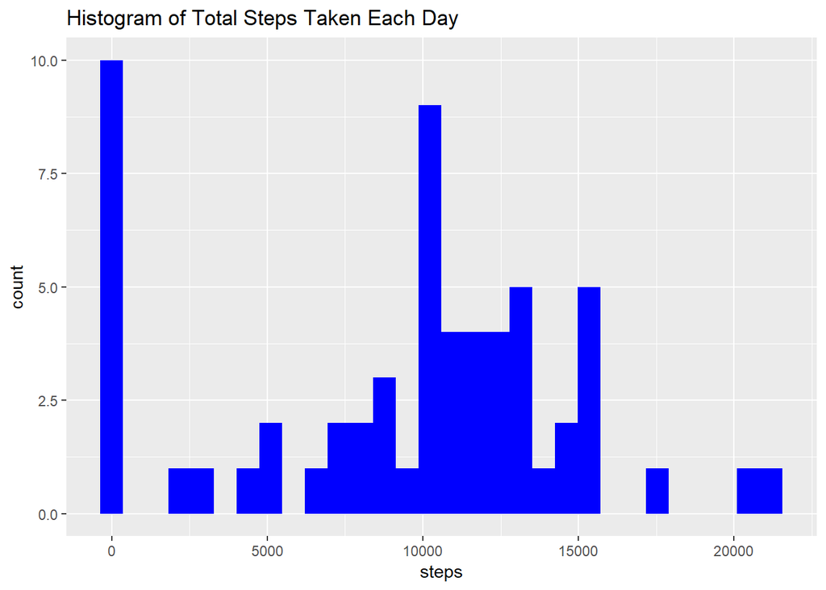

```r
library(ggplot2)
ggplot(data = d2, aes(steps)) + geom_histogram(fill = "blue") + ggtitle("Histogram of Total Steps Taken Each Day")
```

3. The mean and median of the total number of steps taken per day.

```r
me <- mean(d2$steps)
md <- median(d2$steps)
```

The Mean is 9354.2295082 and Median is 10395

**What is the average daily activity pattern?** 1. a time series plot of the 5-minute interval (x-axis) and the average number of steps taken, averaged across all days (y-axis).

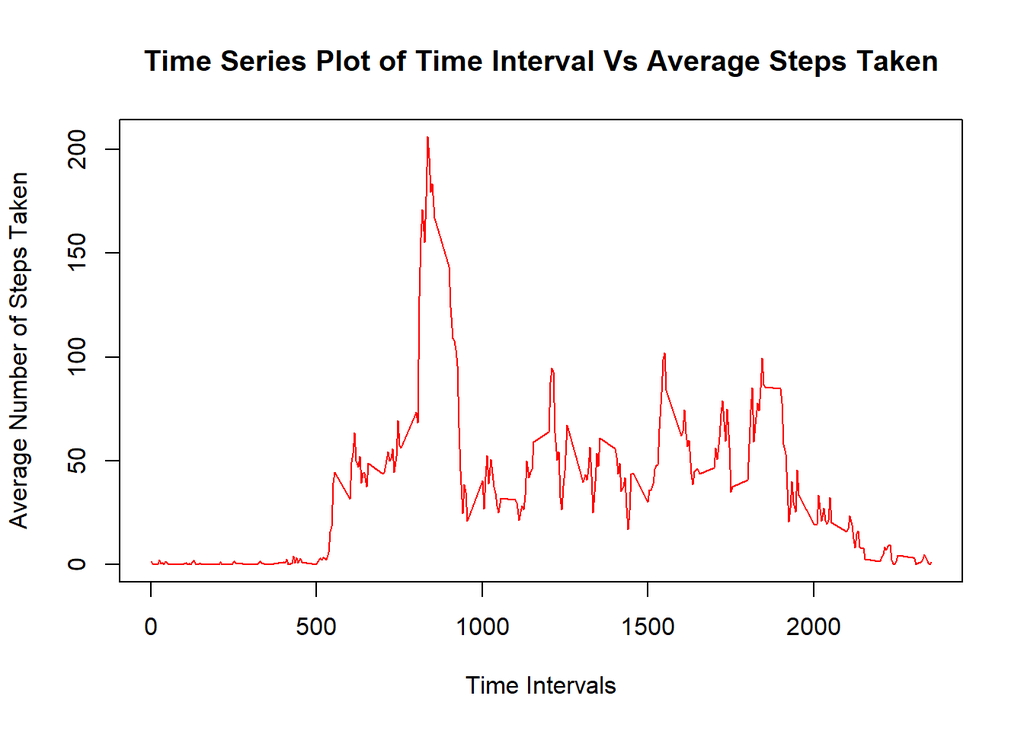

```r
d3 <- summarise(group_by(d1, interval), steps = mean(steps, na.rm = TRUE))
with(d3, plot(interval, steps, type = "l", xlab = "Time Intervals", ylab = "Average Number of Steps Taken", main = "Time Series Plot of Time Interval Vs Average Steps Taken", col = "red"))
```

2. Which 5-minute interval, on average across all the days in the dataset, contains the maximum number of steps?

```r
max.time <- d3[which.max(d3$steps),1]
```

The 5 min interval with maximum number of steps averaged across all the days is 835

**Imputing missing values** 1. The total number of missing values in the dataset

```r
total.na <- sum(is.na(d1$steps))
```

The total NA’s are 2304

2. Devise a strategy for filling in all of the missing values in the dataset. The strategy does not need to be sophisticated.You could use the mean/median for that day, or the mean for that 5-minute interval, etc. Ans == Using the ave() function
3. Create a new dataset that is equal to the original dataset but with the missing data filled in.

```r
d4 <- d1
d4$steps <- ave(d4$steps, d4$interval, FUN = function(x)
ifelse(is.na(x), mean(x,na.rm=TRUE), x))
View(d4)
```

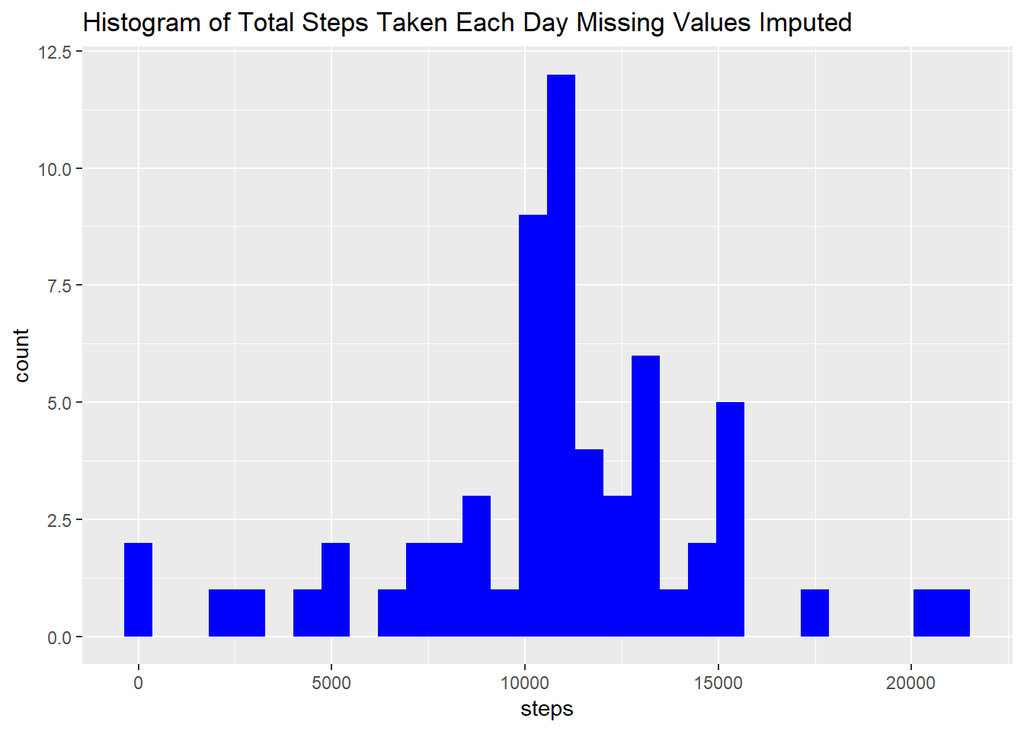

```r
d5 <- summarise(group_by(d4, date), steps = sum(steps))
ggplot(data = d5, aes(steps)) + geom_histogram(fill = "blue") + ggtitle("Histogram of Total Steps Taken Each Day Missing Values Imputed")
```

```r
men <- mean(d5$steps)
mdn <- median(d5$steps)
```

**Are there differences in activity patterns between weekdays and weekends?** 1. Create a new factor variable in the dataset with two levels – “weekday” and “weekend” indicating whether a given date is a weekday or weekend day.

```r
d4$day <- weekdays(d4$date)
d4$day <- ifelse(d4$day=="Saturday"|d4$day=="Sunday", "Weekend", "Weekday")
d4$day <- as.factor(d4$day)
View(d4)
```

2.Make a panel plot containing a time series plot (i.e. type = “l”) of the 5-minute interval (x-axis) and the average number of steps taken, averaged across all weekday days or weekend days (y-axis).

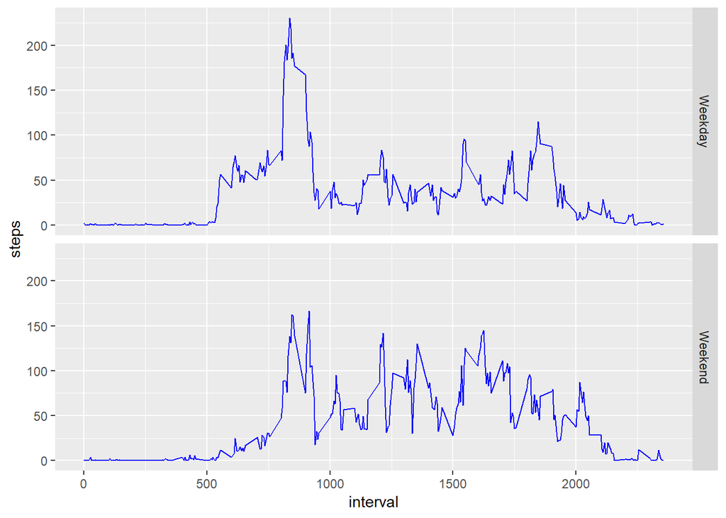

```r
d6 <- summarise(group_by(d4, day, interval), steps = mean(steps))

ggplot(data = d6, aes(interval, steps)) + geom_line(color = "blue") + facet_grid(day~.)
```